# NOAA Storm Data Analysis on Population, Property, and Crops

David Parker

Friday, August 22, 2014

## Synopsis

Analyzing NOAA’s Storm Data to correlate types of weather events that impact human populations. The analysis will summarize data for the time period 1950 to 2011. The results will indicate hazards to people, in terms of injuries and death, as well as economic harm in terms of property and crop damage.

### Loading and Processing the Raw Data

- Using [Storm Data](https://d396qusza40orc.cloudfront.net/repdata%2Fdata%2FStormData.csv.bz2) extracted from the U.S. National Oceanic and Atmospheric Administrations (NOAA) storm database.

## Data Processing

Download the compressed data into a Temp file then read it in compressed form.

**Read small sample** of the data for column names and early classification:

```r
temp <- tempfile()
download.file("http://d396qusza40orc.cloudfront.net/repdata%2Fdata%2FStormData.csv.bz2",
              temp, method = "auto", mode = "wb")
sdata <- read.table(bzfile(temp), comment.char = "#", header = TRUE, sep = ",", nrows = 10,
                    na.strings = "", )
dim(sdata)
```

```
## [1] 10 37
```

```r
cnames <- names(sdata)
cnames
```

```
##  [1] "STATE__"    "BGN_DATE"   "BGN_TIME"   "TIME_ZONE"  "COUNTY"
##  [6] "COUNTYNAME" "STATE"      "EVTYPE"     "BGN_RANGE"  "BGN_AZI"
## [11] "BGN_LOCATI" "END_DATE"   "END_TIME"   "COUNTY_END" "COUNTYENDN"
## [16] "END_RANGE"  "END_AZI"    "END_LOCATI" "LENGTH"     "WIDTH"
## [21] "F"          "MAG"        "FATALITIES" "INJURIES"   "PROPDMG"
## [26] "PROPDMGEXP" "CROPDMG"    "CROPDMGEXP" "WFO"        "STATEOFFIC"
## [31] "ZONENAMES"  "LATITUDE"   "LONGITUDE"  "LATITUDE_E" "LONGITUDE_"
## [36] "REMARKS"    "REFNUM"
```

```r
cnames <- sub("__", "1", cnames, fixed = TRUE)
cnames
```

```
##  [1] "STATE1"     "BGN_DATE"   "BGN_TIME"   "TIME_ZONE"  "COUNTY"
##  [6] "COUNTYNAME" "STATE"      "EVTYPE"     "BGN_RANGE"  "BGN_AZI"
## [11] "BGN_LOCATI" "END_DATE"   "END_TIME"   "COUNTY_END" "COUNTYENDN"
## [16] "END_RANGE"  "END_AZI"    "END_LOCATI" "LENGTH"     "WIDTH"
## [21] "F"          "MAG"        "FATALITIES" "INJURIES"   "PROPDMG"
## [26] "PROPDMGEXP" "CROPDMG"    "CROPDMGEXP" "WFO"        "STATEOFFIC"
## [31] "ZONENAMES"  "LATITUDE"   "LONGITUDE"  "LATITUDE_E" "LONGITUDE_"
## [36] "REMARKS"    "REFNUM"
```

```r
names(sdata) <- cnames
head(sdata[1:10], 3)
```

```
##   STATE1          BGN_DATE BGN_TIME TIME_ZONE COUNTY COUNTYNAME STATE
## 1      1 4/18/1950 0:00:00      130       CST     97     MOBILE    AL
## 2      1 4/18/1950 0:00:00      145       CST      3    BALDWIN    AL
## 3      1 2/20/1951 0:00:00     1600       CST     57    FAYETTE    AL
##    EVTYPE BGN_RANGE BGN_AZI
## 1 TORNADO         0      NA
## 2 TORNADO         0      NA
## 3 TORNADO         0      NA
```

```r
head(sdata[11:20], 3)
```

```
##   BGN_LOCATI END_DATE END_TIME COUNTY_END COUNTYENDN END_RANGE END_AZI
## 1         NA       NA       NA          0         NA         0      NA
## 2         NA       NA       NA          0         NA         0      NA
## 3         NA       NA       NA          0         NA         0      NA
##   END_LOCATI LENGTH WIDTH
## 1         NA   14.0   100
## 2         NA    2.0   150
## 3         NA    0.1   123
```

```r
head(sdata[21:30], 3)
```

```
##   F MAG FATALITIES INJURIES PROPDMG PROPDMGEXP CROPDMG CROPDMGEXP WFO
## 1 3   0          0       15    25.0          K       0         NA  NA
## 2 2   0          0        0     2.5          K       0         NA  NA
## 3 2   0          0        2    25.0          K       0         NA  NA
##   STATEOFFIC
## 1         NA
## 2         NA
## 3         NA
```

```r
head(sdata[31:37], 3)
```

```
##   ZONENAMES LATITUDE LONGITUDE LATITUDE_E LONGITUDE_ REMARKS REFNUM
## 1        NA     3040      8812       3051       8806      NA      1
## 2        NA     3042      8755          0          0      NA      2
## 3        NA     3340      8742          0          0      NA      3
```

```r
str(sdata)
```

```
## 'data.frame':    10 obs. of  37 variables:
##  $ STATE1    : num  1 1 1 1 1 1 1 1 1 1
##  $ BGN_DATE  : Factor w/ 7 levels "1/22/1952 0:00:00",..: 6 6 5 7 2 2 3 1 4 4
##  $ BGN_TIME  : int  130 145 1600 900 1500 2000 100 900 2000 2000
##  $ TIME_ZONE : Factor w/ 1 level "CST": 1 1 1 1 1 1 1 1 1 1
##  $ COUNTY    : num  97 3 57 89 43 77 9 123 125 57
##  $ COUNTYNAME: Factor w/ 9 levels "BALDWIN","BLOUNT",..: 7 1 4 6 3 5 2 8 9 4
##  $ STATE     : Factor w/ 1 level "AL": 1 1 1 1 1 1 1 1 1 1
##  $ EVTYPE    : Factor w/ 1 level "TORNADO": 1 1 1 1 1 1 1 1 1 1
##  $ BGN_RANGE : num  0 0 0 0 0 0 0 0 0 0
##  $ BGN_AZI   : logi  NA NA NA NA NA NA ...
##  $ BGN_LOCATI: logi  NA NA NA NA NA NA ...
##  $ END_DATE  : logi  NA NA NA NA NA NA ...
##  $ END_TIME  : logi  NA NA NA NA NA NA ...
##  $ COUNTY_END: num  0 0 0 0 0 0 0 0 0 0
```

[output cut: 23 more lines]

**Load entire dataset**:

```r
library(Defaults)
# change default date format for data load
setDefaults('as.Date.character', format = '%m/%d/%Y')
# 37 cols,  build appropriate column classes 10 at a time
cclasses <- c("factor", "Date", rep("character", 2), "numeric", "character", "factor", "character", "numeric", "factor",
              rep("character", 3), "numeric", "character", "numeric", "factor", "character", rep("numeric", 2),
              "factor", rep("numeric", 4), "character", "numeric", "character",  rep("character", 2),
              rep("character", 7))
cclasses
```

```
##  [1] "factor"    "Date"      "character" "character" "numeric"
##  [6] "character" "factor"    "character" "numeric"   "factor"
## [11] "character" "character" "character" "numeric"   "character"
## [16] "numeric"   "factor"    "character" "numeric"   "numeric"
## [21] "factor"    "numeric"   "numeric"   "numeric"   "numeric"
## [26] "character" "numeric"   "character" "character" "character"
## [31] "character" "character" "character" "character" "character"
## [36] "character" "character"
```

```r
# load entire dataset
sdata <- read.table(bzfile(temp), comment.char = "#", header = TRUE, sep = ",",
                    colClasses = cclasses, na.strings = "")
names(sdata) <- cnames
dim(sdata)
```

```
## [1] 902297     37
```

```r
summary(sdata)
```

```
##      STATE1          BGN_DATE            BGN_TIME
##  48.00  : 83728   Min.   :1950-01-03   Length:902297
##  20.00  : 53441   1st Qu.:1995-04-20   Class :character
##  40.00  : 46802   Median :2002-03-18   Mode  :character
##  29.00  : 35648   Mean   :1998-12-27
##  19.00  : 31069   3rd Qu.:2007-07-28
##  31.00  : 30271   Max.   :2011-11-30
##  (Other):621338
##   TIME_ZONE             COUNTY     COUNTYNAME            STATE
##  Length:902297      Min.   :  0   Length:902297      TX     : 83728
##  Class :character   1st Qu.: 31   Class :character   KS     : 53440
##  Mode  :character   Median : 75   Mode  :character   OK     : 46802
##                     Mean   :101                      MO     : 35648
##                     3rd Qu.:131                      IA     : 31069
##                     Max.   :873                      NE     : 30271
##                                                      (Other):621339
##     EVTYPE            BGN_RANGE       BGN_AZI        BGN_LOCATI
##  Length:902297      Min.   :   0   N      : 86752   Length:902297
##  Class :character   1st Qu.:   0   W      : 38446   Class :character
##  Mode  :character   Median :   0   S      : 37558   Mode  :character
##                     Mean   :   1   E      : 33178
##                     3rd Qu.:   1   NW     : 24041
##                     Max.   :3749   (Other):134990
##                                    NA's   :547332
##    END_DATE           END_TIME           COUNTY_END  COUNTYENDN
##  Length:902297      Length:902297      Min.   :0    Length:902297
##  Class :character   Class :character   1st Qu.:0    Class :character
##  Mode  :character   Mode  :character   Median :0    Mode  :character
##                                        Mean   :0
##                                        3rd Qu.:0
##                                        Max.   :0
##
##    END_RANGE      END_AZI        END_LOCATI            LENGTH
##  Min.   :  0   N      : 28082   Length:902297      Min.   :   0.0
##  1st Qu.:  0   S      : 22510   Class :character   1st Qu.:   0.0
##  Median :  0   W      : 20119   Mode  :character   Median :   0.0
##  Mean   :  1   E      : 20047                      Mean   :   0.2
##  3rd Qu.:  0   NE     : 14606                      3rd Qu.:   0.0
##  Max.   :925   (Other): 72096                      Max.   :2315.0
##                NA's   :724837
```

[output cut: 33 more lines]

```
##  Length:902297      Length:902297      Length:902297
##  Class :character   Class :character   Class :character
##  Mode  :character   Mode  :character   Mode  :character
##
##
##
##
##     REFNUM
##  Length:902297
##  Class :character
##  Mode  :character
##
##
##
##
```

```r
# Data is loaded, drop the temp compressed file
unlink(temp)
```

**Make date field**:

```r
# compare dates for initial date concatenation
head(sdata[, c(2:4)])
```

```
##     BGN_DATE BGN_TIME TIME_ZONE
## 1 1950-04-18     0130       CST
## 2 1950-04-18     0145       CST
## 3 1951-02-20     1600       CST
## 4 1951-06-08     0900       CST
## 5 1951-11-15     1500       CST
## 6 1951-11-15     2000       CST
```

```r
sdata$BEGIN_DATE <-
  as.POSIXct(
    paste(sdata$BGN_DATE, sdata$BGN_TIME, sdata$TIME_ZONE)
    , format=  "%Y-%m-%d %H%M")
head(sdata[, c(2:4, 38)])
```

```
##     BGN_DATE BGN_TIME TIME_ZONE          BEGIN_DATE
## 1 1950-04-18     0130       CST 1950-04-18 01:30:00
## 2 1950-04-18     0145       CST 1950-04-18 01:45:00
## 3 1951-02-20     1600       CST 1951-02-20 16:00:00
## 4 1951-06-08     0900       CST 1951-06-08 09:00:00
## 5 1951-11-15     1500       CST 1951-11-15 15:00:00
## 6 1951-11-15     2000       CST 1951-11-15 20:00:00
```

```r
# place BEGIN_DATE in appropiate position
sdata <- sdata[, c(1, 38, 2:37)]
dim(sdata)
```

```
## [1] 902297     38
```

```r
# save sdata during testing
# save(sdata, file = 'sdata.Rdata')
```

**Tidy the data**:

```r
library(plyr)
etype <- sort(unique(sdata$EVTYPE))
etype
```

```
##   [1] "   HIGH SURF ADVISORY"          " COASTAL FLOOD"
##   [3] " FLASH FLOOD"                   " LIGHTNING"
##   [5] " TSTM WIND"                     " TSTM WIND (G45)"
##   [7] " WATERSPOUT"                    " WIND"
##   [9] "?"                              "ABNORMAL WARMTH"
##  [11] "ABNORMALLY DRY"                 "ABNORMALLY WET"
##  [13] "ACCUMULATED SNOWFALL"           "AGRICULTURAL FREEZE"
##  [15] "APACHE COUNTY"                  "ASTRONOMICAL HIGH TIDE"
##  [17] "ASTRONOMICAL LOW TIDE"          "AVALANCE"
##  [19] "AVALANCHE"                      "BEACH EROSIN"
##  [21] "Beach Erosion"                  "BEACH EROSION"
##  [23] "BEACH EROSION/COASTAL FLOOD"    "BEACH FLOOD"
##  [25] "BELOW NORMAL PRECIPITATION"     "BITTER WIND CHILL"
##  [27] "BITTER WIND CHILL TEMPERATURES" "Black Ice"
##  [29] "BLACK ICE"                      "BLIZZARD"
```

[output cut: 478 more lines]

```r
# clean up EVTYPE field
sdata$EVTYPE <- toupper(sdata$EVTYPE)
sdata$EVTYPE <- sub("^\\s+", "", sdata$EVTYPE)
sdata$EVTYPE <- gsub('/', ' ', sdata$EVTYPE)

# first examine health data
# summarize by EVTYPE, examine initial values > 0
health <- ddply(sdata, .(EVTYPE), summarize, SFATAL=sum(FATALITIES), SINJURY=sum(INJURIES))

health <- health[health$SFATAL > 0| health$SINJURY > 0, ]
health[order(-health$SINJURY, -health$SFATAL), ]
```

```
##                             EVTYPE SFATAL SINJURY
## 739                        TORNADO   5633   91346
## 760                      TSTM WIND    504    6957
## 146                          FLOOD    470    6789
## 108                 EXCESSIVE HEAT   1903    6525
## 406                      LIGHTNING    816    5230
## 233                           HEAT    937    2100
## 376                      ICE STORM     89    1975
## 130                    FLASH FLOOD    978    1777
## 669              THUNDERSTORM WIND    133    1488
## 202                           HAIL     15    1361
## 866                   WINTER STORM    206    1321
## 360              HURRICANE TYPHOON     64    1275
## 308                      HIGH WIND    248    1137
## 263                     HEAVY SNOW    127    1021
```

[output cut: 189 more lines]

```r
# Create a new Event Type field to better summarize
# add an entry for every significant type, init w/'OTHER'
sdata$TYPE <- "OTHER"
# load primary TYPES
sdata[grepl('TORNADO', sdata$EVTYPE),  ]$TYPE <- "TORNADO"
sdata[grepl('WIND', sdata$EVTYPE),  ]$TYPE <- "WIND"
sdata[grepl('HEAT', sdata$EVTYPE),  ]$TYPE <- "HEAT"
sdata[grepl('WARM', sdata$EVTYPE),  ]$TYPE <- "HEAT"
sdata[grepl('FLOOD', sdata$EVTYPE),  ]$TYPE <- "FLOOD"
sdata[grepl('FLD', sdata$EVTYPE),  ]$TYPE <- "FLOOD"
sdata[grepl('LIGHTN', sdata$EVTYPE),  ]$TYPE <- "LIGHTNING"
sdata[grepl('ICE', sdata$EVTYPE),  ]$TYPE <- "ICE"
sdata[grepl('WINTER', sdata$EVTYPE),  ]$TYPE <- "WINTER WEATHER"
sdata[grepl('WINTRY', sdata$EVTYPE),  ]$TYPE <- "WINTER WEATHER"
sdata[grepl('FIRE', sdata$EVTYPE),  ]$TYPE <- "FIRE"
sdata[grepl('HAIL', sdata$EVTYPE),  ]$TYPE <- "HAIL"
# hurricane & typhoon is a form of tropical cyclone
sdata[grepl('HURRICANE', sdata$EVTYPE),  ]$TYPE <- "CYCLONE"
sdata[grepl('TYPHOON', sdata$EVTYPE),  ]$TYPE <- "CYCLONE"
sdata[grepl('SNOW', sdata$EVTYPE),  ]$TYPE <- "SNOW"
sdata[grepl('FOG', sdata$EVTYPE),  ]$TYPE <- "FOG"
sdata[grepl('ICY', sdata$EVTYPE),  ]$TYPE <- "FOG"
sdata[grepl('FOG', sdata$EVTYPE),  ]$TYPE <- "FOG"
sdata[grepl('BLIZZ', sdata$EVTYPE),  ]$TYPE <- "BLIZZARD"
sdata[grepl('RIP', sdata$EVTYPE),  ]$TYPE <- "RIP CURRENTS"
sdata[grepl('DUST', sdata$EVTYPE),  ]$TYPE <- "DUST STORM"
sdata[grepl('TROPIC', sdata$EVTYPE),  ]$TYPE <- "TROPICAL STORM"
sdata[grepl('RAIN', sdata$EVTYPE),  ]$TYPE <- "RAIN"
sdata[grepl('COLD', sdata$EVTYPE),  ]$TYPE <- "COLD"
sdata[grepl('HYPOTH', sdata$EVTYPE),  ]$TYPE <- "COLD"
sdata[grepl('FREEZ', sdata$EVTYPE),  ]$TYPE <- "COLD"
sdata[grepl('FROST', sdata$EVTYPE),  ]$TYPE <- "COLD"
sdata[grepl('AVALAN', sdata$EVTYPE),  ]$TYPE <- "AVALANCHE"
sdata[grepl('SEAS', sdata$EVTYPE),  ]$TYPE <- "HIGH SEAS"
sdata[grepl('SURF', sdata$EVTYPE),  ]$TYPE <- "HIGH SEAS"
# sdata[grepl('TSUN', sdata$EVTYPE),  ]$TYPE <- "TSUNAMI"
# sdata[grepl('LANDS', sdata$EVTYPE),  ]$TYPE <- "LANDSLIDE"
sdata[grepl('SURGE', sdata$EVTYPE),  ]$TYPE <- "STORM SURGE"
sdata[grepl('TSTM', sdata$EVTYPE),  ]$TYPE <- "THUNDERSTORM"
sdata[grepl('THUNDER', sdata$EVTYPE),  ]$TYPE <- "THUNDERSTORM"
sdata[grepl('WATERSP', sdata$EVTYPE),  ]$TYPE <- "WATERSPOUT"
# many DROUGHT combos, override above others in one DROUGHT category
sdata[grepl('DROUGHT', sdata$EVTYPE),  ]$TYPE <- "DROUGHT"
# See major TYPES
type <- sort(unique(sdata$TYPE))
type
```

```
##  [1] "AVALANCHE"      "BLIZZARD"       "COLD"           "CYCLONE"
##  [5] "DROUGHT"        "DUST STORM"     "FIRE"           "FLOOD"
##  [9] "FOG"            "HAIL"           "HEAT"           "HIGH SEAS"
## [13] "ICE"            "LIGHTNING"      "OTHER"          "RAIN"
## [17] "RIP CURRENTS"   "SNOW"           "STORM SURGE"    "THUNDERSTORM"
## [21] "TORNADO"        "TROPICAL STORM" "WATERSPOUT"     "WIND"
## [25] "WINTER WEATHER"
```

```r
sdata <- transform(sdata, TYPE = factor(TYPE))
```

**Analyze the Tidy data**

```r
# summary(sdata$BEGIN_DATE)
summary(sdata$BGN_DATE)
```

```
##         Min.      1st Qu.       Median         Mean      3rd Qu.
## "1950-01-03" "1995-04-20" "2002-03-18" "1998-12-27" "2007-07-28"
##         Max.
## "2011-11-30"
```

```r
# summarize damage estimates for health
health <- ddply(sdata, .(TYPE), summarize,
                FATALITY=sum(FATALITIES, na.rm = TRUE), INJURY=sum(INJURIES, na.rm = TRUE))
health
```

```
##              TYPE FATALITY INJURY
## 1       AVALANCHE      225    171
## 2        BLIZZARD      101    805
## 3            COLD      470    361
## 4         CYCLONE      135   1333
## 5         DROUGHT        6     19
## 6      DUST STORM       24    483
## 7            FIRE       90   1608
## 8           FLOOD     1552   8681
## 9             FOG       85   1107
## 10           HAIL       15   1371
## 11           HEAT     3132   9211
## 12      HIGH SEAS      231    296
## 13            ICE       97   2154
## 14      LIGHTNING      817   5231
## 15          OTHER      118    473
## 16           RAIN      106    282
## 17   RIP CURRENTS      572    529
## 18           SNOW      148   1162
## 19    STORM SURGE       24     43
## 20   THUNDERSTORM      756   9545
## 21        TORNADO     5633  91364
## 22 TROPICAL STORM       66    383
## 23     WATERSPOUT        6     72
## 24           WIND      457   1876
## 25 WINTER WEATHER      279   1968
```

```r
healthy <- ddply(sdata, .((format(sdata$BGN_DATE, '%Y')), TYPE), summarize,
                FATALITY=sum(FATALITIES, na.rm = TRUE), INJURY=sum(INJURIES, na.rm = TRUE))
colnames(healthy)[1] <- c("YEAR")
tail(healthy)
```

```
##     YEAR           TYPE FATALITY INJURY
## 586 2011   THUNDERSTORM       57    387
## 587 2011        TORNADO      587   6163
## 588 2011 TROPICAL STORM        4      1
## 589 2011     WATERSPOUT        0      0
## 590 2011           WIND       16     49
## 591 2011 WINTER WEATHER        3      0
```

```r
# ready for health analysis results

# now examine property & crop economic damage
# limit the data frame to only needed columns for economic data
ldata <- sdata[, c(3, 26, 27, 28, 29, 39)]
summary(ldata)
```

```
##     BGN_DATE             PROPDMG      PROPDMGEXP           CROPDMG
##  Min.   :1950-01-03   Min.   :   0   Length:902297      Min.   :  0.0
##  1st Qu.:1995-04-20   1st Qu.:   0   Class :character   1st Qu.:  0.0
##  Median :2002-03-18   Median :   0   Mode  :character   Median :  0.0
##  Mean   :1998-12-27   Mean   :  12                      Mean   :  1.5
##  3rd Qu.:2007-07-28   3rd Qu.:   0                      3rd Qu.:  0.0
##  Max.   :2011-11-30   Max.   :5000                      Max.   :990.0
##
##   CROPDMGEXP                    TYPE
##  Length:902297      THUNDERSTORM  :336818
##  Class :character   HAIL          :289281
##  Mode  :character   FLOOD         : 86073
##                     TORNADO       : 60684
##                     WIND          : 26553
##                     WINTER WEATHER: 19693
##                     (Other)       : 83195
```

```r
names(ldata)
```

```
## [1] "BGN_DATE"   "PROPDMG"    "PROPDMGEXP" "CROPDMG"    "CROPDMGEXP"
## [6] "TYPE"
```

```r
edata <- ddply(ldata, .(TYPE, PROPDMGEXP, CROPDMGEXP), summarize,
              PROPDMG = sum(PROPDMG, na.rm=T), CROPDMG = sum(CROPDMG,na.rm=T))
head(edata,3)
```

```
##        TYPE PROPDMGEXP CROPDMGEXP PROPDMG CROPDMG
## 1 AVALANCHE          K          K   285.8       0
## 2 AVALANCHE          K       <NA>  1336.0       0
## 3 AVALANCHE          M          K     2.1       0
```

```r
# examine yearly breakdown
edatay <- ddply(ldata, .(TYPE, (format(BGN_DATE, '%Y')), PROPDMGEXP, CROPDMGEXP), summarize,
              PROPDMG = sum(PROPDMG, na.rm=T), CROPDMG = sum(CROPDMG,na.rm=T))
colnames(edatay)[2] <- c("YEAR")
tail(edatay)
```

```
##                TYPE YEAR PROPDMGEXP CROPDMGEXP  PROPDMG CROPDMG
## 2144 WINTER WEATHER 2009          M          K    16.00       0
## 2145 WINTER WEATHER 2010          K          K 12053.30       0
## 2146 WINTER WEATHER 2010          K          M     0.00      15
## 2147 WINTER WEATHER 2010          M          K    52.60       0
## 2148 WINTER WEATHER 2011          K          K 13302.00      70
## 2149 WINTER WEATHER 2011          M          K     6.75       0
```

```r
# Focus on areas where damages are in Billions of dollars
bdamage <- edata[edata$PROPDMGEXP %in% ('B')|edata$CROPDMGEXP %in% ('B'), ]
# calaculate damages for crops, property and total in billions
damage <- ddply(bdamage, .(TYPE), summarize, PROPERTY = round(sum(PROPDMG)),
               CROPS = round(sum(CROPDMG)),
               DAMAGES = (round(sum(PROPDMG)) + round(sum(CROPDMG))))
# Damages in Billions
damage
```

```
##              TYPE PROPERTY CROPS DAMAGES
## 1            COLD        0     0       0
## 2         CYCLONE       74  1546    1620
## 3         DROUGHT        0     2       2
## 4            FIRE        3     6       9
## 5           FLOOD      128    38     166
## 6            HAIL        2     0       2
## 7            HEAT        0     0       0
## 8             ICE      500     5     505
## 9            RAIN        2     0       2
## 10    STORM SURGE       47     0      47
## 11   THUNDERSTORM        3     2       5
## 12        TORNADO        5     0       5
## 13 TROPICAL STORM        5     0       5
## 14           WIND        1     0       1
## 15 WINTER WEATHER        5     0       5
```

```r
# Focus on areas by Year where damages are in Billions of dollars
bdamagey <- edatay[edatay$PROPDMGEXP %in% ('B')|edatay$CROPDMGEXP %in% ('B'), ]
# calaculate damages for crops, property and total in billions
damagey <- ddply(bdamagey, .(YEAR, TYPE), summarize, PROPERTY = round(sum(PROPDMG)),
               CROPS = round(sum(CROPDMG)),
               DAMAGES = (round(sum(PROPDMG)) + round(sum(CROPDMG))))
# Damages in Billions
damagey
```

```
##    YEAR           TYPE PROPERTY CROPS DAMAGES
## 1  1993          FLOOD        5     5      10
## 2  1993   THUNDERSTORM        2     2       4
## 3  1993 WINTER WEATHER        5     0       5
## 4  1994            ICE      500     5     505
## 5  1995           COLD        0     0       0
## 6  1995        CYCLONE        3    15      18
## 7  1995        DROUGHT        0     0       0
## 8  1995           HEAT        0     0       0
## 9  1995           RAIN        2     0       2
## 10 1995   THUNDERSTORM        1     0       1
## 11 1997          FLOOD        3     0       3
## 12 1998        CYCLONE        2   301     303
## 13 1999        CYCLONE        3   500     503
## 14 2000           FIRE        2     0       2
```

[output cut: 16 more lines]

```r
# ready for results
```

## Results

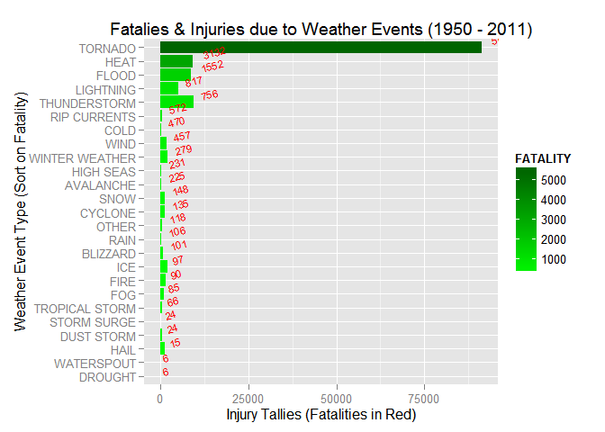

```r
library(ggplot2)
# plot summary health effects
health2 <- health[health$FATALITY > 0 & health$INJURY > 0, ]
health2$TYPE <- factor(health$TYPE, levels=health[order(health$FATALITY), "TYPE"])

h <- ggplot(health2, aes(y = INJURY,  x = TYPE, fill = FATALITY)) + coord_flip()
h <- h + geom_bar(stat = 'identity', binwidth = 2)
h <- h + scale_fill_gradient(low="green",high="darkgreen")
h <- h + labs(title = 'Fatalies & Injuries due to Weather Events (1950 - 2011)')
h <- h + xlab('Weather Event Type (Sort on Fatality)')
h <- h + ylab('Injury Tallies (Fatalities in Red)')
h <- h + geom_text(size=3,  angle = 15, color='red', hjust=-0.5, vjust=0, aes(label=FATALITY))
print(h)
```

Tornadoes are far and away the most significant threat in terms of injury and loss of life.

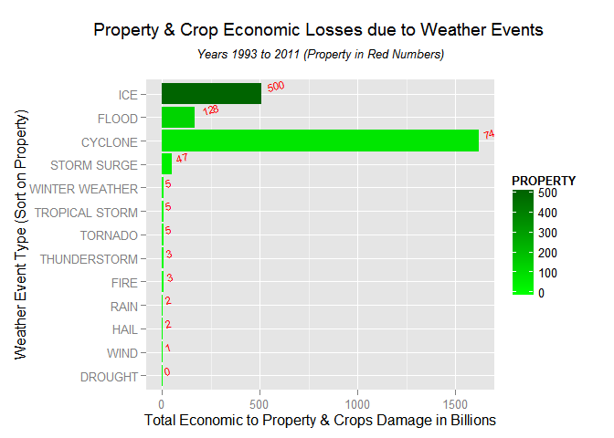

```r
# plot summary property & crop damages
damage <- damage[order(-damage$DAMAGES), ]
# plot DAMAGES >= 1 billion
damage2 <- damage[damage$DAMAGES >= 1, ]
damage2$TYPE <- factor(damage2$TYPE, levels=damage2[order(damage2$PROPERTY), "TYPE"])

e <- ggplot(damage2, aes(y = DAMAGES,  x = TYPE,  fill = PROPERTY)) + coord_flip()
e <- e + geom_bar(stat = 'identity', binwidth = 1)
e <- e + scale_fill_gradient(low="green",high="darkgreen")
e <- e + ggtitle(expression(atop('Property & Crop Economic Losses due to Weather Events ',
                                 atop(italic('Years 1993 to 2011 (Property in Red Numbers)'), ""))))
e <- e + xlab('Weather Event Type (Sort on Property)')
e <- e + ylab('Total Economic to Property & Crops Damage in Billions')
e <- e + geom_text(size=3,  angle = 15, color='red', hjust=-0.5, vjust=0, aes(label=PROPERTY))
print(e)
```

Cyclones (Hurricanes and Tropical Cyclones) generate the most total losses for property and crops combined, but most of this damage is to crops. The types are sorted in terms of damage to property indicating that ice and flooding are a greater threat to property followed by cyclones.

```r
# plot summary property & crop damages
damagey <- damagey[order(damagey$YEAR, -damagey$DAMAGES), ]
# plot DAMAGES >= 1 billion
damagey2 <- damagey[damagey$DAMAGES >= 1, ]
damagey2
```

```
##    YEAR           TYPE PROPERTY CROPS DAMAGES
## 1  1993          FLOOD        5     5      10
## 3  1993 WINTER WEATHER        5     0       5
## 2  1993   THUNDERSTORM        2     2       4
## 4  1994            ICE      500     5     505
## 6  1995        CYCLONE        3    15      18
## 9  1995           RAIN        2     0       2
## 10 1995   THUNDERSTORM        1     0       1
## 11 1997          FLOOD        3     0       3
## 12 1998        CYCLONE        2   301     303
## 13 1999        CYCLONE        3   500     503
## 14 2000           FIRE        2     0       2
## 15 2001 TROPICAL STORM        5     0       5
## 16 2003           FIRE        1     6       7
## 17 2003          FLOOD        1     0       1
## 18 2004        CYCLONE       17   428     445
## 19 2004           WIND        1     0       1
## 20 2005        CYCLONE       49   302     351
## 21 2005    STORM SURGE       43     0      43
## 23 2006          FLOOD      115    32     147
## 22 2006        DROUGHT        0     1       1
## 25 2008    STORM SURGE        4     0       4
## 24 2008        CYCLONE        1     0       1
## 26 2010          FLOOD        2     1       3
## 27 2010           HAIL        2     0       2
## 30 2011        TORNADO        5     0       5
## 29 2011          FLOOD        3     0       3
```

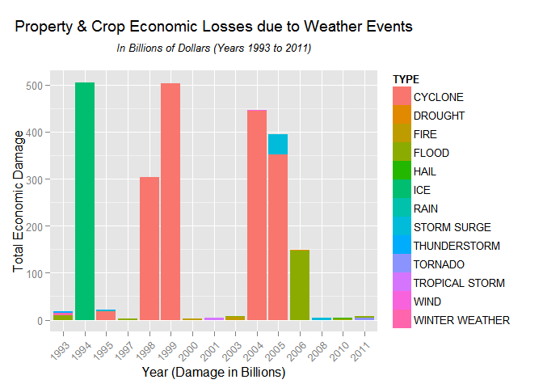

```r
e <- ggplot(damagey2, aes(y = DAMAGES,  x = YEAR,  fill = TYPE))
e <- e + geom_bar(stat = 'identity', binwidth = 1)
e <- e + ggtitle(expression(atop('Property & Crop Economic Losses due to Weather Events',
                                 atop(italic('In Billions of Dollars (Years 1993 to 2011)'), ""))))
e <- e + xlab('Year (Damage in Billions)') + theme(axis.text.x = element_text(angle = 45, hjust = 1))
e <- e + ylab('Total Economic Damage')
print(e)
```

Major weather events have Significant impact in damages to crops and property.